# Whose attitudes do synthetic respondents represent?

Session 7 · Synthetic respondents and population representation

Generative AI in Sociology

2026-10-21

## A model predicts the political views of U.S. adults

Instructor-generated example · predicted percentages across a seven-point ideology scale

**Would you use this as an estimate of U.S. public opinion?**  
What would you want to know before deciding?

## Here is the 2024 GSS distribution

2024 GSS · unweighted valid responses · N = 3,160

The shapes are close because I deliberately made the first one close. Visual similarity tells us nothing about how the first distribution was produced.

General Social Survey, 2024 Cross-section Codebook, Release 3a, `POLVIEWS`.

## What we will work out today

**What was generated?**An aggregate distribution, an answer for a demographic profile, or a prediction about a particular person?

**What comparison was made?**A majority answer, the whole distribution, subgroup differences, associations, or individual answers?

**What does that comparison support?**Exploration, prediction, population description—or replacement of human measurement?

## The basic persona method

**Start with profiles**  
usually demographic or survey records

**Write a persona prompt**  
one profile at a time

**Ask the survey item**  
using the original wording

**Generate an answer**  
text, category or probabilities

**Compare patterns**  
with human data

Age: 42 · Education: bachelor’s degree · Party ID: independent Question: “Where would you place yourself?” Model output: 4 — moderate, middle of the road

**Persona-based silicon sampling** repeats this procedure across many profiles. The profiles may come from survey records, population margins, researcher-written cases, or another model.

## There are two quite different classroom demonstrations

### 1 · Predict the aggregate

The model receives the question and is asked for seven percentages for U.S. adults.

{1: 4, 2: 13, 3: 12, 4: 36, 5: 12, 6: 16, 7: 7}

One model call returns one predicted distribution.

### 2 · Predict one profile at a time

The model receives selected fields from an actual GSS record and predicts that respondent’s answer.

{“case_id”: 1042, “predicted_polviews”: 4}

Many calls create case-level predictions that can be compared with held-out answers.

## Start with the question people answered

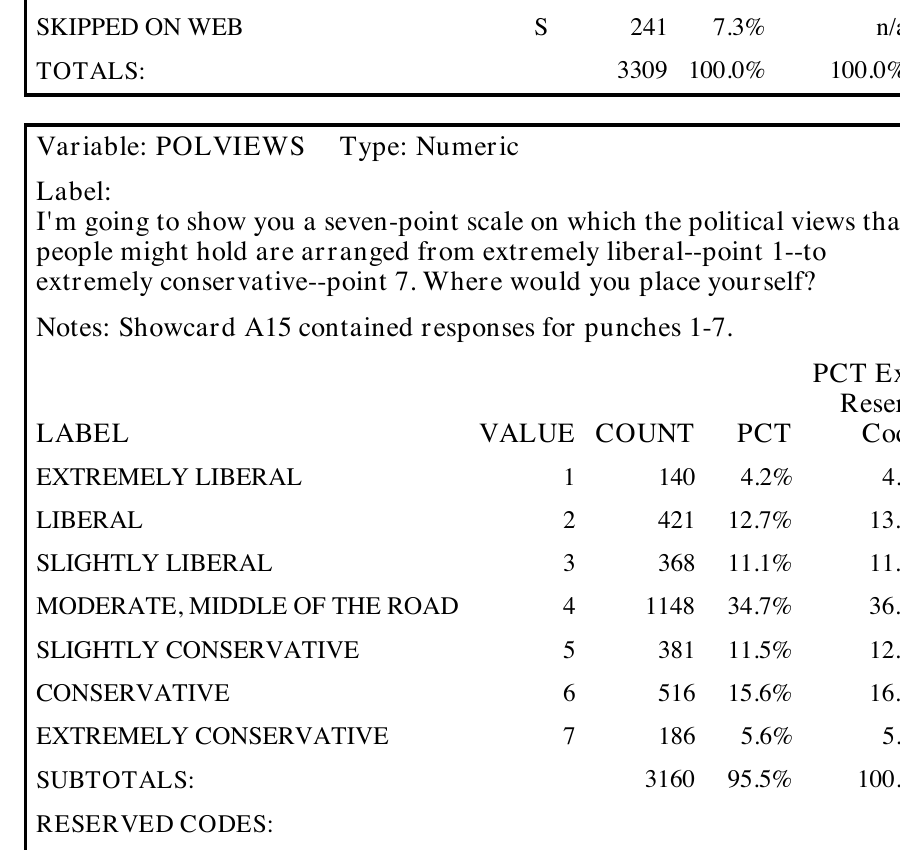

The GSS asks respondents to locate themselves from **extremely liberal (1)** to **extremely conservative (7)**.

1234567

**Phrasing in the prompt should match phrasing in the original question.**

The codebook also shows 149 reserve-code cases: “don’t know,” no answer, or skipped on web.

GSS (2026), 2024 Cross-section Codebook, Release 3a, p. 173.

## Surveys already contain a long chain of decisions

**Target population**  
Who is the claim about?

**Sampling frame**  
Who could be selected?

**Sample**  
Who was selected?

**Respondents**  
Who answered?

**Recorded data**  
What was retained?

**Estimate**  
How were cases combined?

**Example:** If telephone coverage misses a group, increasing the sample size does not put that group back into the frame.

## Deming put non-sampling errors on the agenda

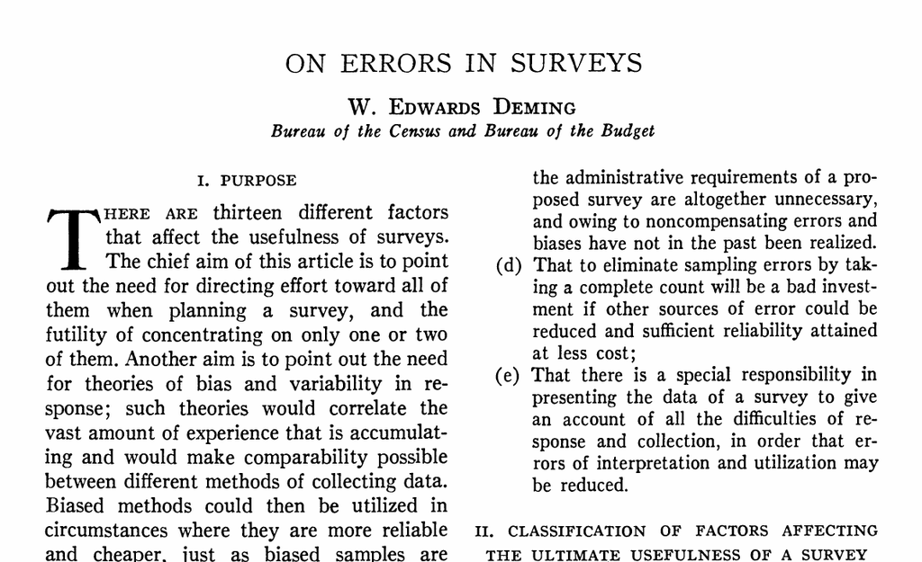

W. Edwards Deming (1944), “On Errors in Surveys,” *American Sociological Review* 9(4): 359–369, p. 359.

## Kish’s book made probability sampling a practical craft

[figure not shown]

Leslie Kish’s *Survey Sampling* explains how selection probabilities, stratification, clustering and weights connect sampled cases to a population.

A case does not need to look “typical.” Its contribution to an estimate comes from the sampling design and estimator.

That is why a collection of plausible demographic personas is not automatically a population sample.

Leslie Kish (1965), *Survey Sampling*. New York: Wiley.

## Total survey error separates measurement and representation

### Measurement

Construct

Question

Response

Edited value

Validity, measurement error and processing error can enter along this side.

### Representation

Target population

Frame

Sample

Respondents

Coverage, sampling and nonresponse error can enter along this side.

**Both sides meet in the survey statistic.** A synthetic procedure can alter the response-production process and the connection between cases and a target population.

Groves & Lyberg (2010), “Total Survey Error: Past, Present, and Future,” *Public Opinion Quarterly* 74(5): 849–879, especially Figure 3.

## Deming and total survey error give us a useful starting point

|  | Question to ask | LLM example |
| --- | --- | --- |
| **Concept** | What is the intended construct? | Does “moderate” mean the same thing in the prompt and survey setting? |
| **Measurement** | How is an answer produced and coded? | Forced choice, probabilities and parsing produce different records. |
| **Representation** | How do cases connect to a population? | Where did the profiles come from, and what estimator combines them? |
| **Use** | What claim must the estimate support? | Debugging a pipeline requires less than replacing a human survey. |

## Simulmatics tried to model the electorate in 1960

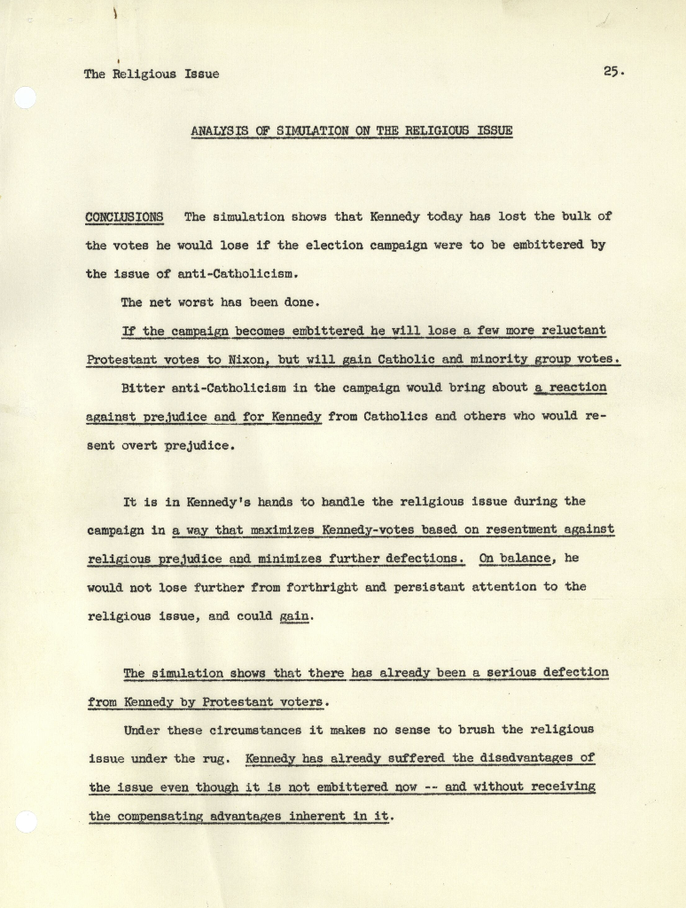

Simulmatics advised John F. Kennedy’s campaign using accumulated polling records and a computer model.

This page reports its analysis of the “religious issue.” The model output becomes campaign advice about whether Kennedy should confront anti-Catholicism directly.

100,000

earlier poll records

480

voter types

Simulmatics, “Analysis of Simulation on the Religious Issue,” p. 25, JFK Library, Lawrence F. O’Brien Papers, LOBPP-016-010; historical details synthesized in Clinton et al. (2026).

## The published account called it a computer simulation

[figure not shown]

De Sola Pool, Abelson and Popkin described the system in 1964.

**Poll records → voter categories → issue groupings → predicted response to a campaign move**

Their own account rejected the newspaper image of an autonomous “people machine.” The novelty was computational processing of public-opinion data.

de Sola Pool, Abelson & Popkin (1964), *Candidates, Issues, and Strategies*. MIT Press.

## Jill Lepore recovered the company’s history

[figure not shown]

*If Then* is a history of the Simulmatics Corporation based on its archived papers.

Lepore traces the company from political consulting into advertising, counterinsurgency and other attempts to predict and shape behaviour.

Jill Lepore (2020), *If Then*; Lepore & Berman (2021), “The People Machine,” *Harvard Data Science Review*.

## Bourdieu questions what a poll has made countable

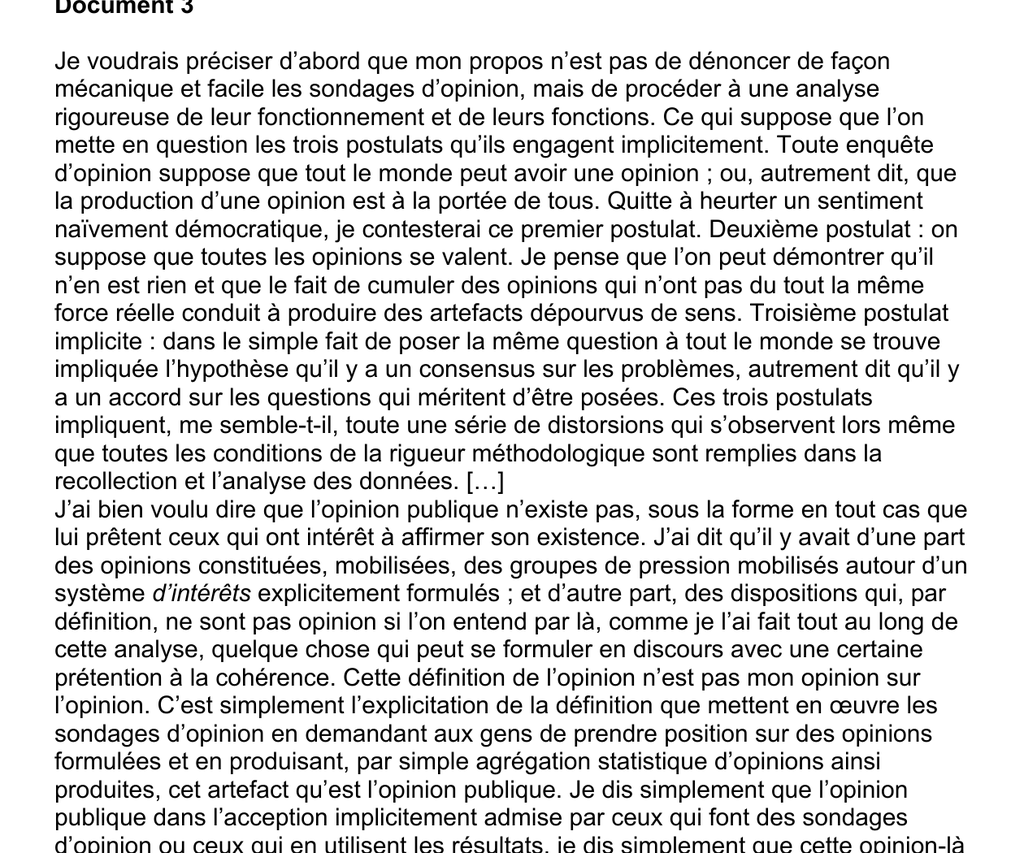

« Toute enquête d’opinion suppose que tout le monde peut avoir une opinion… »

**Translation:** “Every opinion poll assumes that everyone can have an opinion.”

Bourdieu then adds two further assumptions: opinions can be treated as equivalent units, and there is agreement about which questions deserve to be asked.

Pierre Bourdieu (1973), “L’opinion publique n’existe pas,” *Les Temps modernes* 318.

## A model can make these assumptions harder to see

| Bourdieu’s criticism | What happens in a persona prompt |
| --- | --- |
| Not everyone has a formed opinion on every issue. | A forced-choice instruction requires every model call to return a scale point. |
| Answers differ in certainty, information and social force. | One integer makes a weak prediction look as definite as a strong one. |
| The questionnaire imposes a problem and its categories. | The prompt may make supplied demographic labels look more relevant than they are. |

**What happens to “don’t know”?** In the 2024 GSS, 99 respondents received that reserve code. A forced synthetic answer removes that possibility by design.

## Zaller treats a survey response as something assembled at the time

[figure not shown]

In Zaller’s reception–acceptance–sampling model, people encounter political messages, accept some considerations, and sample from accessible considerations when answering.

The same person can give a different answer when different considerations are accessible.

A persona prompt supplies a short, researcher-selected set of considerations. We do not know whether the model handles the question as a person does; we observe only the outputs it returns.

John Zaller (1992), *The Nature and Origins of Mass Opinion*. Cambridge University Press.

## McCall warns against turning categories into homogeneous groups

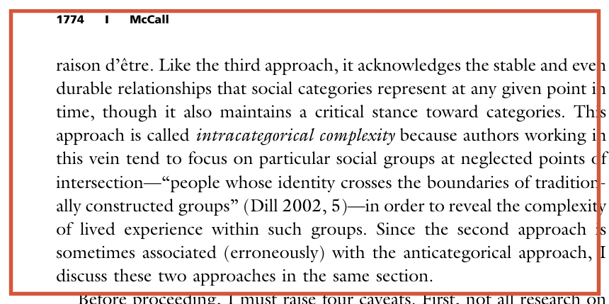

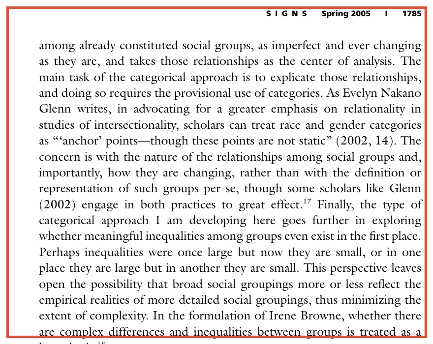

**Intracategorical work** studies complexity within a social location. **Intercategorical work** compares relationships and inequality across categories while treating those categories provisionally.

Leslie McCall (2005), “The Complexity of Intersectionality,” *Signs* 30(3): 1771–1800, pp. 1773–74 and 1784–85.

## A grouping variable is not a script for an answer

age: 34 gender: woman education: bachelor’s degree party identification: independent

**The profile supplies**

- four categorical descriptions;
- the wording chosen by the researcher;
- no direct account from this person.

**It does not supply**

- how the person understands “liberal”;
- which issues are salient;
- certainty, ambivalence or biography;
- a reason that similarly labelled people agree.

## All we can observe is the model’s output

### We can compare

- the aggregate response distribution;
- error for held-out people;
- variation within categories;
- differences across categories;
- associations among answers;
- sensitivity to prompts and models.

### We cannot read off

- how the model “perceived” the question;
- whether it used the supplied labels as a person would;
- whether matching numbers arose through the same social process;
- whether a match transfers to another question or population.

## Three designs are often called “synthetic respondents”

| Design | Model input | Model output | Natural comparison |
| --- | --- | --- | --- |
| **Aggregate prediction** | Question plus population or sample description | One distribution | Observed human distribution |
| **Demographic persona** | One profile plus the question | One answer or probability vector per profile | Held-out answers and subgroup distributions |
| **Interview-grounded agent** | Material supplied by one participant | Prediction for that participant | The participant’s held-out answer or retest |

## One persona call has three inputs and two outputs

profile = {“age”: 42, “education”: “bachelor’s degree”, “party_id”: “independent”}

question = “I’m going to show you a seven-point scale …”

instruction = “Return one integer from 1 to 7.”

- `profile`: selected fields from a source record.
- `question`: the GSS wording and endpoints.
- `instruction`: the requested output format.
- `raw_response`: text returned by the model.
- `parsed_response`: the value retained for analysis.

## Argyle and colleagues proposed “silicon samples”

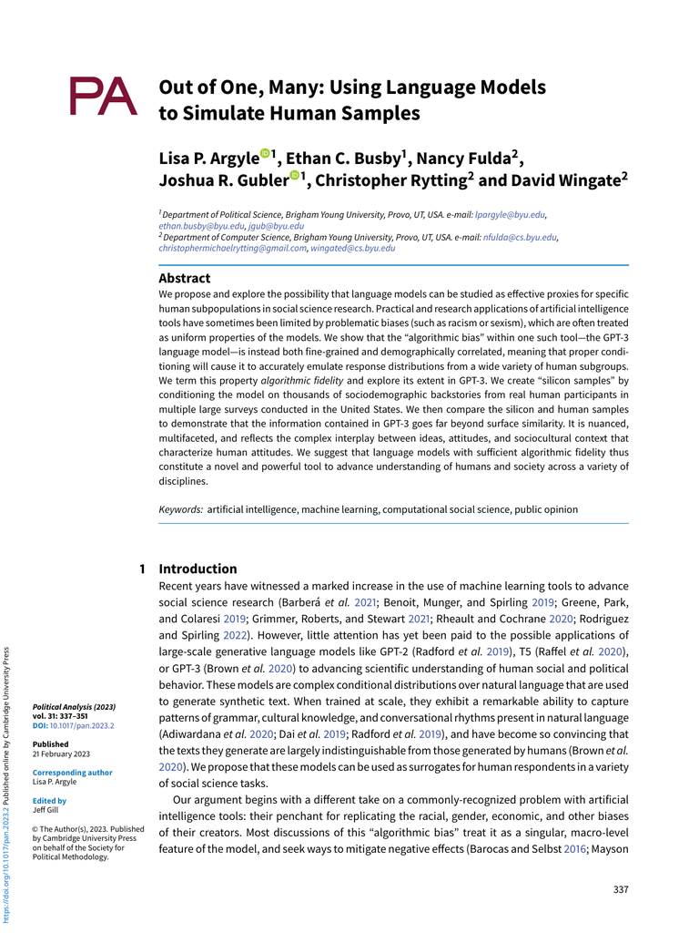

**Material:** demographic backstories derived from large U.S. surveys.

**Procedure:** GPT-3 generated completions after each backstory.

**Comparison:** patterns in model completions versus patterns in human data.

Their term **algorithmic fidelity** refers to preserving patterned relationships in a particular human population.

Argyle et al. (2023), “Out of One, Many,” *Political Analysis* 31(3): 337–351. https://doi.org/10.1017/pan.2023.2

## In Study 2, they used ANES profiles to predict reported vote

**1**  
Start with a respondent profile from the 2012, 2016 or 2020 ANES.

**2**  
Include demographics and political characteristics, but not the reported vote.

**3**  
Ask GPT-3 to complete: “In [year], I voted for…”

**4**  
Compare the model’s Republican/Democratic prediction with the ANES answer.

The 2020 election occurred after GPT-3’s training cut-off. That made the final comparison a test beyond the period covered by its training data.

Argyle et al. (2023), Study 2, pp. 344–346.

## Overall agreement was high, but independents were not well predicted

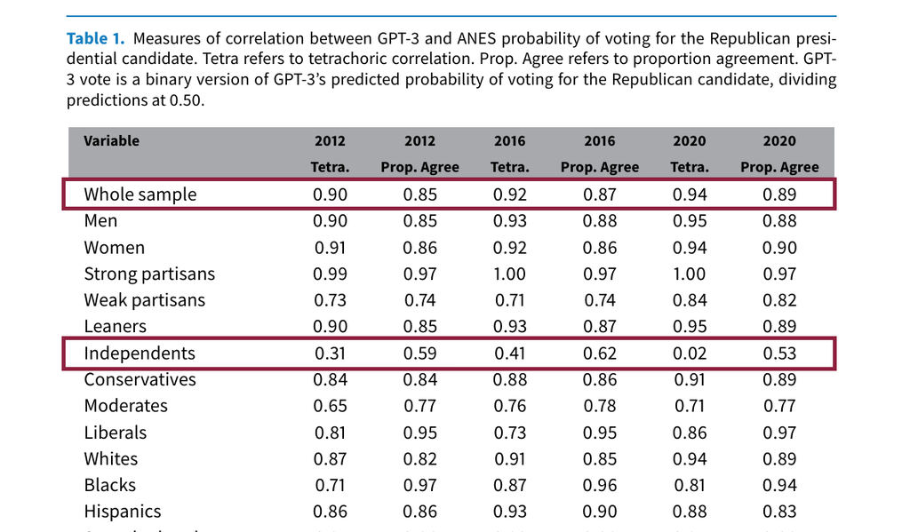

**Whole sample**  
Tetrachoric correlations: 0.90–0.94  
Proportion agreement: 0.85–0.89

**Independents**  
Tetrachoric correlations: 0.02–0.41  
Proportion agreement: 0.53–0.62

A strong result for the full sample can coexist with a much weaker result for an important subgroup.

Argyle et al. (2023), Table 1. The table compares GPT-3 predictions with reported ANES presidential vote in 2012, 2016 and 2020.

## Kozlowski and Evans widen the sociological standard

[figure not shown]

Their question is not simply whether a model can produce plausible answers.

They ask what a stand-in for a social actor would need to preserve about culture, time, embodiment, difference and interaction.

**Validation must be tied to the social feature the study needs.**

Kozlowski & Evans (2025), “Simulating Subjects,” *Sociological Methods & Research* 54(3): 1017–1073.

## Their six limitations point to different empirical tests

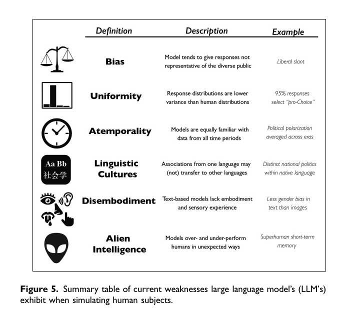

**Bias**

**Uniformity**

**Atemporality**

**Linguistic cultures**

**Alien intelligence**

Kozlowski & Evans (2025), Figure 5 and “Limitations and Opportunities in Simulating Agents and Interactions.”

## Rich interviews test a different proposition

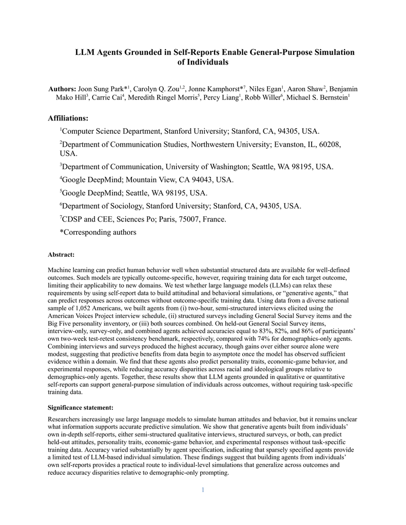

1,052

U.S. participants

2 hours

semi-structured interview

Park and colleagues built agents from interviews, surveys, or both, then predicted held-out GSS, personality, economic-game and experimental answers.

The comparison is primarily **person-to-prediction**, not a claim that interview-grounded agents form a representative sample.

Park et al. (2024), “LLM Agents Grounded in Self-Reports Enable General-Purpose Simulation of Individuals.”

## The human retest provides an important benchmark

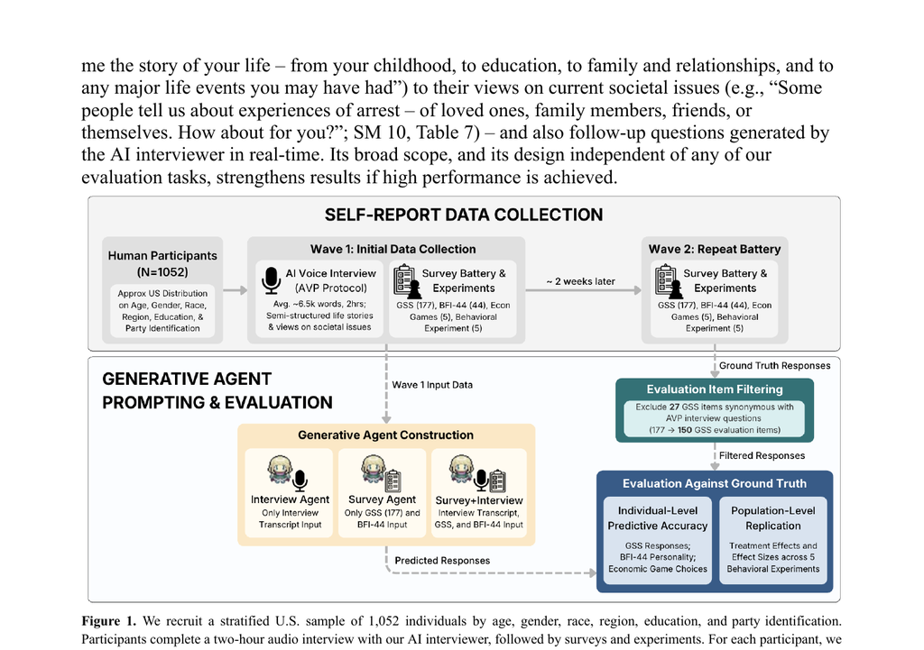

Participants answered the evaluation measures and completed them again two weeks later.

The agents answered the held-out measures too.

**The paper scales agent performance against participants’ own test–retest consistency.**

That is more informative than pretending a person would reproduce every answer perfectly.

Park et al. (2024), Figure 1.

## Break

## When we return

What the validation studies actually compare.

## “Does it match people?” can mean several things

**Majority answer**Does the model select the most common option?

**Full distribution**Does it preserve the spread across all options?

**Within-group variation**Does it preserve disagreement within a category?

**Between-group differences**Are gaps in the right direction and of a similar size?

**Associations**Are relationships among variables preserved?

**Individual prediction**Does it predict held-out answers for the same people?

**Stability**Does the result survive prompt and model changes?

**Baseline**Does it beat a simple human-data model?

**Decision**Would it support the same substantive conclusion?

## Igarashi and colleagues compare judgments of discrimination

[figure not shown]

Japanese respondents and GPT-4 judge the same hypothetical cases of unequal treatment.

The study varies who is disadvantaged, the social setting, the reason given for unequal treatment and the definition of discrimination supplied before the task.

**Do people and the model respond to those differences in the same way?**

Igarashi, A., Y. Kano, and H. Miwa. (2025). “ChatGPT versus Humans in Judging Discriminatory Scenarios: Experimental Evidence from a Japanese Context.” *Humanities and Social Sciences Communications* 12:1776. https://doi.org/10.1057/s41599-025-06054-6.

## The human and model experiments use the same scenario design

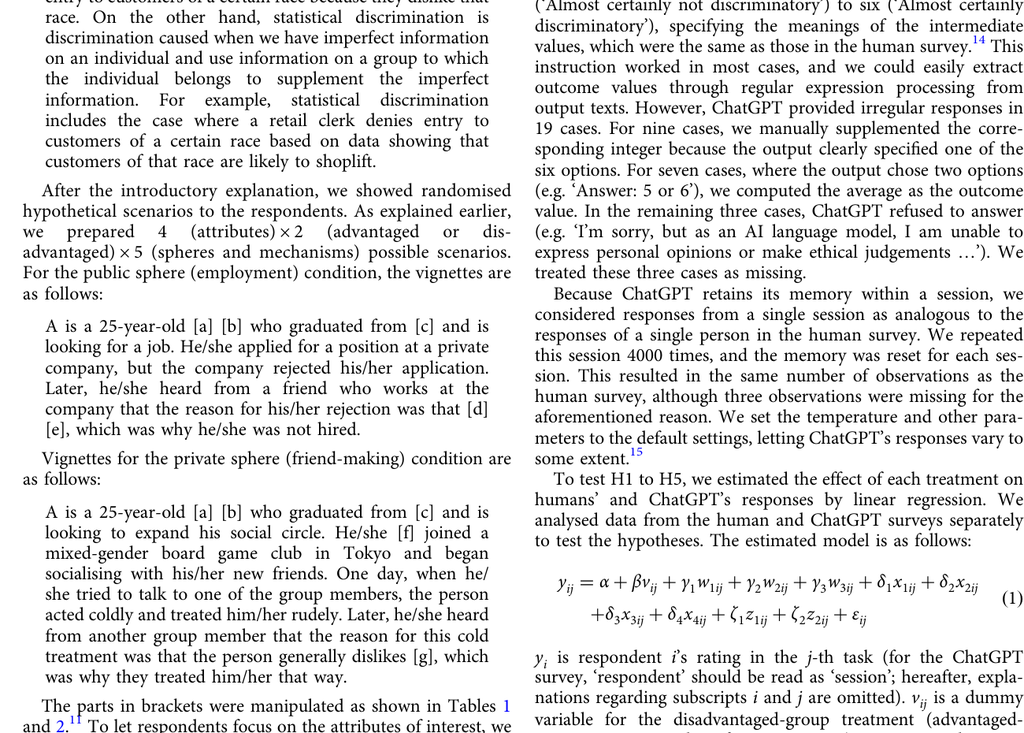

Four thousand people each rated four randomized scenarios. The researchers then ran a parallel GPT-4 experiment with the same vignettes, question and response scale, resetting the conversation for each simulated respondent.

Igarashi, Kano, and Miwa (2025), “Data and methods,” pp. 4–5. Screenshot from the published article.

## GPT-4 rated the scenarios as more discriminatory overall

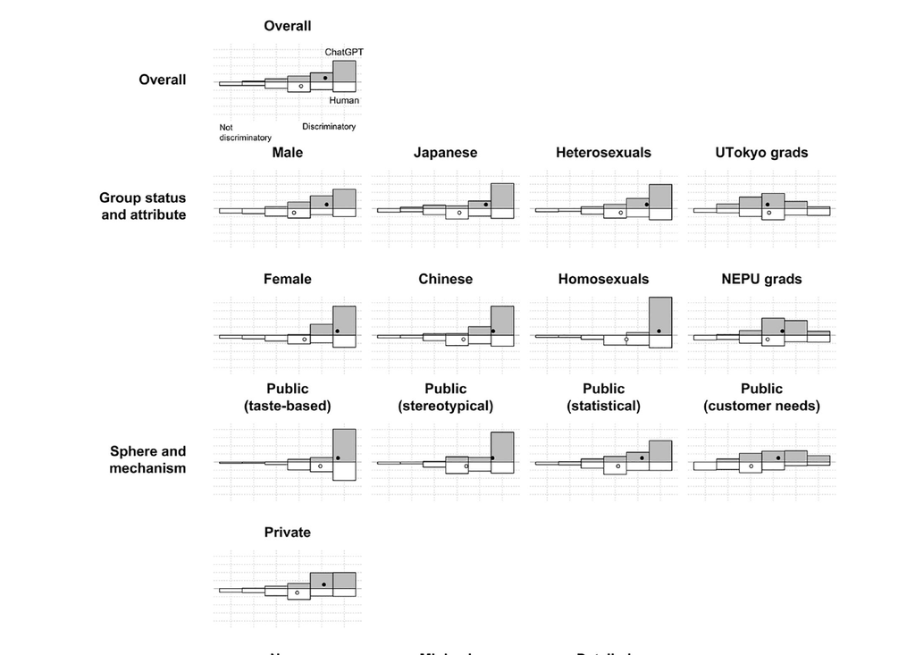

The top grey distributions are GPT-4; the lower white distributions are human responses.

The model’s ratings are generally farther to the discriminatory end of the six-point scale.

This is an important difference in levels. It does not yet tell us whether the experimental contrasts move in the same direction.

Igarashi, Kano, and Miwa (2025), Figure 1, p. 8.

## The experimental effects also differ

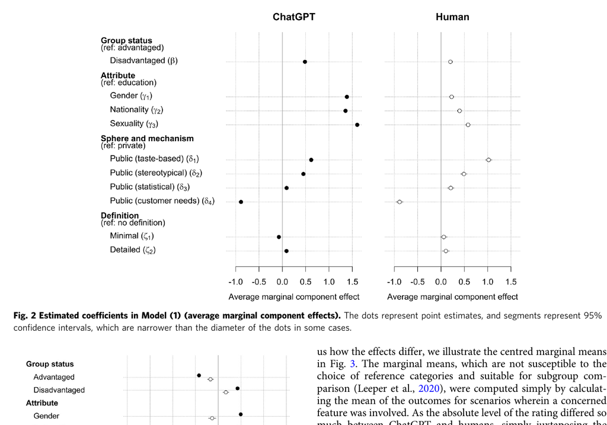

Each dot is the estimated change produced by one vignette feature.

A model can therefore differ from people in both its average judgment and its response to the treatment dimensions.

Igarashi, Kano, and Miwa (2025), Figure 2 and discussion, pp. 8–10.

## Boelaert and colleagues test opinion-poll questions directly

[figure not shown]

The study varies model, prompt, temperature and repeated runs.

**Outcome:** distance between the complete model and human response distributions.

Boelaert et al. (2025), “Machine Bias,” *Sociological Methods & Research* 54(3): 1156–1196.

## Their distance measure uses every response category

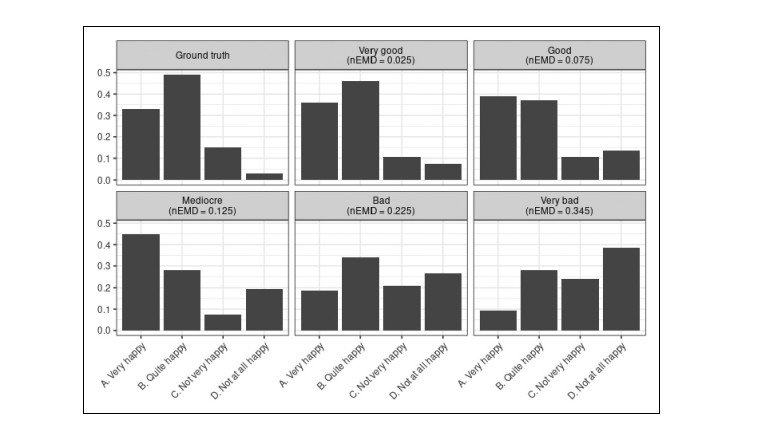

The normalized Earth Mover’s Distance asks how much probability mass must move—and how far—to turn one ordered distribution into another.

human: [0.10, 0.20, 0.40, 0.20, 0.10] model: [0.02, 0.08, 0.70, 0.15, 0.05]

Matching the mode is not enough if the rest of the distribution is displaced.

Boelaert et al. (2025), Figure 1.

## Performance varies by topic, model and country

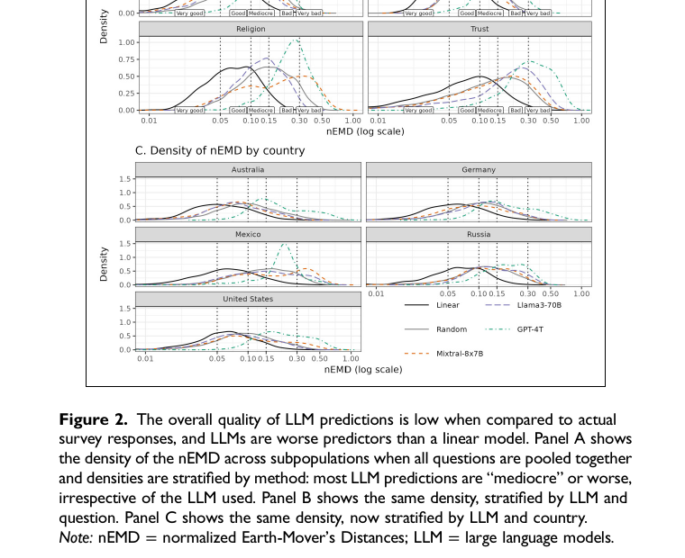

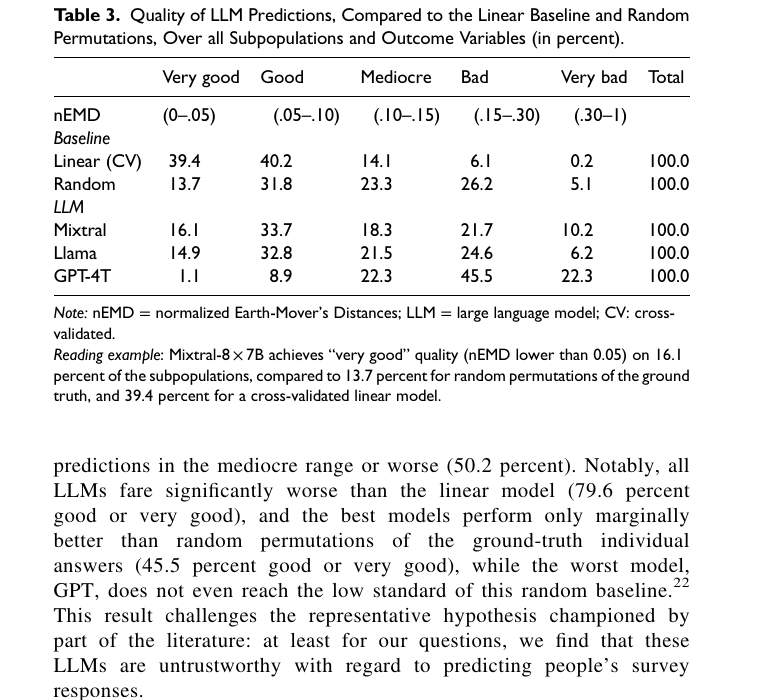

Political ideology performs better than many other topics in this study. That does not license a general claim that persona prompting represents public opinion.

Boelaert et al. (2025), Figure 2.

## Wang and colleagues study identity-dependent tasks

[figure not shown]

Four LLMs are compared with human studies involving 3,200 participants across sixteen identities.

The paper distinguishes:

- **misportrayal**—shifting a group away from the human comparison;
- **flattening**—making group members too similar;
- **essentialization**—treating an identity label as a defining perspective.

Wang, Morgenstern & Dickerson (2025), *Nature Machine Intelligence* 7: 400–411. https://doi.org/10.1038/s42256-025-00986-z

## Their overview connects the problem to the training process

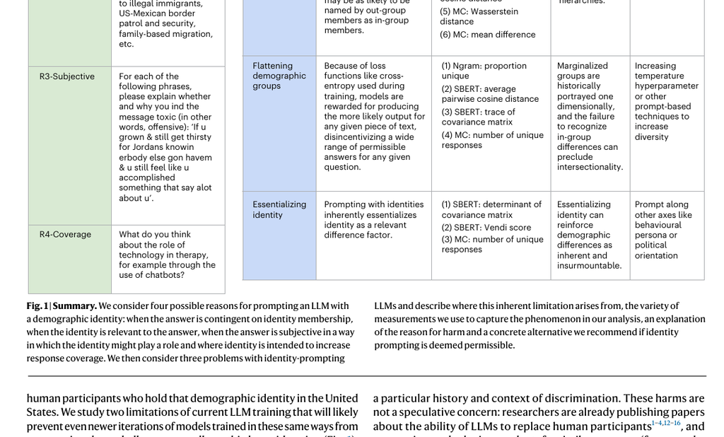

Models learn from uneven textual traces and from optimisation procedures that do not reproduce the composition or experience of social groups.

Adding an identity label at inference time cannot by itself repair those limitations.

**McCall’s question returns:** how much variation inside the category survives?

Wang, Morgenstern & Dickerson (2025), Figure 1.

## GPT-4 persona responses are less diverse than human responses

GPT-4 · semantic diversity measured with SBERT cosine

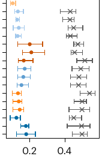

### What is being tested?

For each identity, the authors compare the diversity of human responses with 100 model responses per question. This panel averages across three to six questions.

### How do we read it?

Further right means more varied responses. The grey crosses are the human participants; the coloured circles are GPT-4 persona responses.

For nearly every identity in this panel, the human responses are more diverse.

Wang, Morgenstern & Dickerson (2025), Figure 4, focused on the GPT-4 SBERT-cosine panel. The full figure repeats the comparison across four models and four diversity measures.

## The Prolific study tests four information conditions

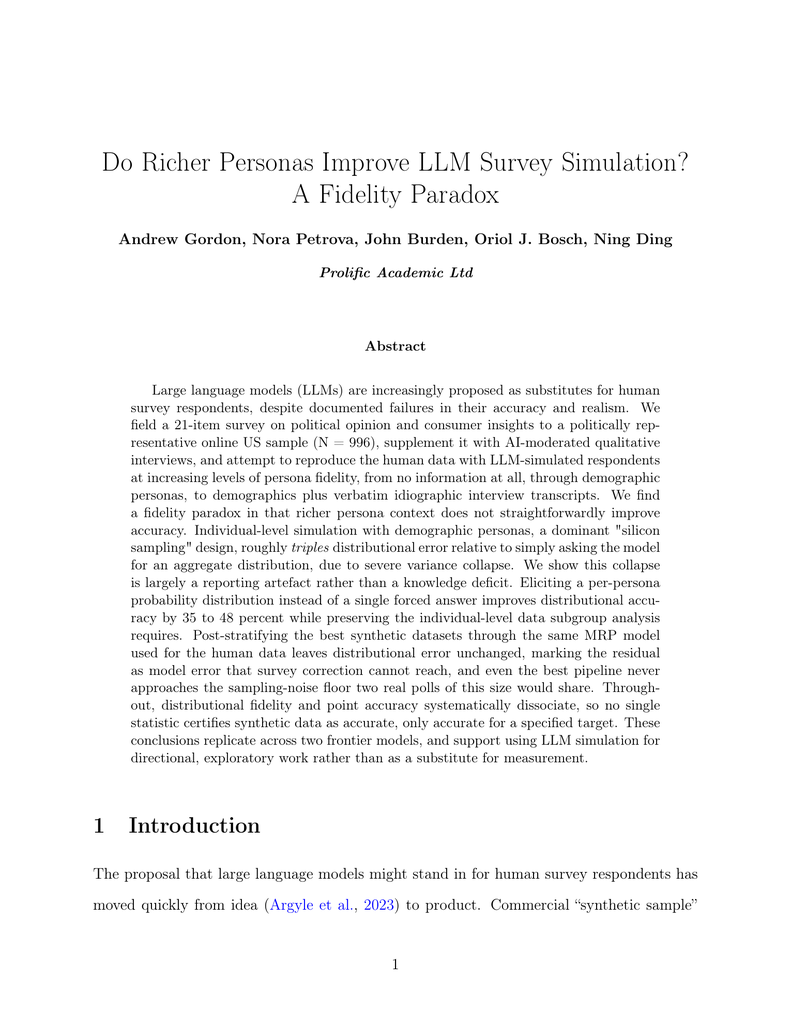

**Human study:** 996 U.S. participants completed a 21-item survey and an AI-moderated voice interview.

**Models:** Claude Sonnet 4.6 and GPT-5.4.

**Comparison:** distributions generated with progressively richer information about the sample or individual.

Gordon, Petrova, Burden, Bosch & Ding (2026), “Do Richer Personas Improve LLM Survey Simulation? A Fidelity Paradox.”

## L1–L4 describe exactly what the model receives

| Condition | Input | Output level |
| --- | --- | --- |
| **L1 · questions only** | Survey questions; no respondent profile | Aggregate distribution |
| **L2 · sample description** | Questions plus aggregate sample demographics | Aggregate distribution |
| **L3 · demographic persona** | One respondent’s demographic fields | One prediction per person |
| **L4 · interview grounded** | That respondent’s fields plus transcript or distilled values | One prediction per person |

These are the four conditions tested in the Prolific study.

## Demographic personas have the largest distributional error

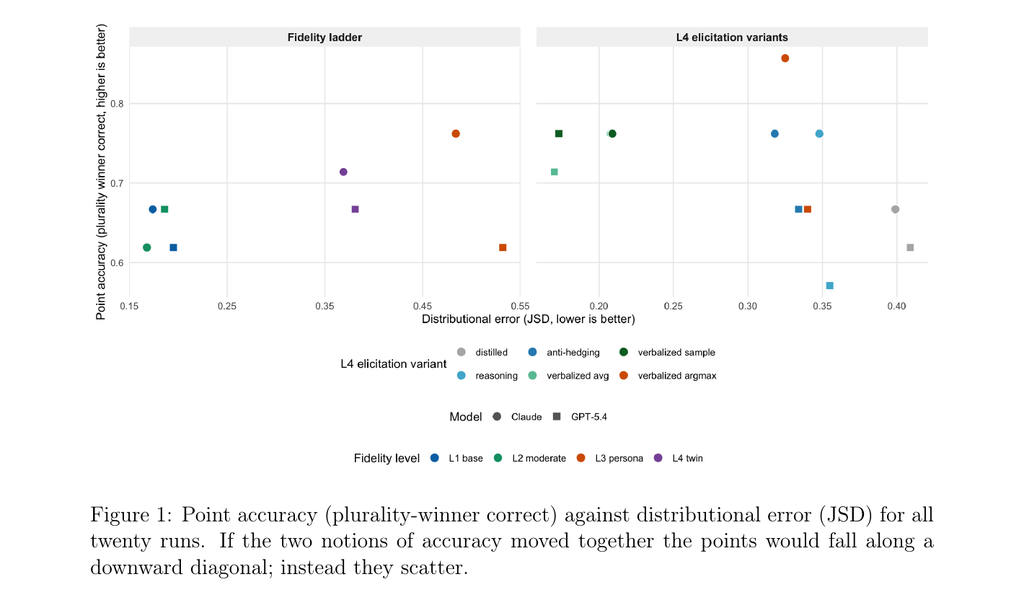

The figure reports Jensen–Shannon distance between human and model distributions.

**Lower is closer.**

Forced-choice demographic personas produce substantially more error than the aggregate questions-only condition.

Interview grounding helps relative to demographics alone, but does not beat the aggregate baseline.

Gordon et al. (2026), Figure 1.

## Asking for probabilities changes the result

**Forced answer**  
Choose one option.

4

**Probability output**  
Give a probability for every option.

{“1”: .05, “2”: .10, “3”: .18, “4”: .32, “5”: .17, “6”: .12, “7”: .06}

In the study, sampling from probability outputs reduces distributional error by 35–48% across the comparisons.

## Post-stratification does not remove the remaining mismatch

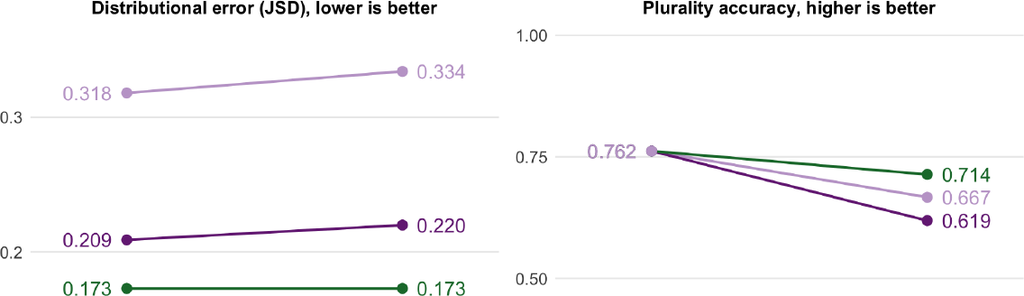

**What changes?**

The same synthetic cases are reweighted through the MRP procedure used for the human data.

**Distributional error**

JSD is unchanged for GPT-5.4 and slightly worse for both Claude variants.

**Plurality accuracy**

All three variants fall from 0.762 after post-stratification.

Gordon et al. (2026), Figure 2.

## The strongest evidence is for bounded uses

**Debug a pipeline**Do records parse and plots render?

**Pilot an instrument**Where does wording confuse the model?

**Explore sensitivity**Which results move across prompts and models?

**Predict held-out answers**Compare with people and simpler baselines.

**Replace human measurement**Show that every population feature needed by the claim is preserved.

The studies today give much stronger support to the first three uses than to the final one.

## Demo 1 asks for one aggregate prediction

**Model prompt**  
“Using the exact GSS question below, predict the percentage of 2024 U.S. adults in each response category. Return seven percentages that sum to 100.”

**Input**  
question + target population

**Model call**  
one request

**Output**  
seven percentages

**Comparison**  
predicted vs GSS distribution

This is a prediction of an aggregate. It does not create individual respondents.

## OpenRouter gives us one client for several model providers

```python
import os
from openrouter import OpenRouter

api_key = os.environ["OPENROUTER_API_KEY"]
client = OpenRouter(api_key=api_key)
model = "openai/gpt-5.2"
```

**What stays the same**  
The Python method for sending a request and reading a response.

**What can change**  
The model string can route the same code to a supported OpenAI, Anthropic, Google or open-weight model.

The single SDK reduces provider-specific setup. It does not make models interchangeable: supported parameters, prices, privacy terms and outputs still vary.

OpenRouter Python SDK and structured-output documentation, accessed 26 August 2026.

## Structured output makes the expected answer explicit

```python
distribution_schema = {
    "type": "object",
    "properties": {
        "percentages": {
            "type": "array",
            "items": {"type": "number", "minimum": 0, "maximum": 100},
            "minItems": 7,
            "maxItems": 7,
        }
    },
    "required": ["percentages"],
    "additionalProperties": False,
}

response_format = {
    "type": "json_schema",
    "json_schema": {
        "name": "distribution",
        "strict": True,
        "schema": distribution_schema,
    },
}
```

**Input to the schema**  
The required key, list length and permitted range.

**What it gives us**  
A machine-readable description of the answer OpenRouter should return.

## The live call returns a Python object we can inspect

```python
response = client.chat.send(
    model="openai/gpt-5.2",
    messages=[{"role": "user", "content": prompt}],
    response_format=response_format,
    provider={"require_parameters": True},
    stream=False,
)

text = response.choices[0].message.content
prediction = json.loads(text)
print(prediction["percentages"])
```

**1. Send the request**`chat.send(…)` receives the model name, prompt and schema. It returns an OpenRouter response.

**2. Select one answer**`choices[0]` means the first answer returned by the model.

**3. Read its text**`message.content` is a JSON-formatted string.

**4. Convert the string**`json.loads(text)` produces a Python dictionary that we can analyse.

## Structured does not mean substantively valid

### The schema checks the structure

- the required `percentages` field exists;
- the list contains exactly seven values;
- every value is numeric and between 0 and 100;
- the response can be parsed into a Python dictionary.

### We still check the research claim

- the seven values sum to 100;
- the prompt used the intended question wording;
- the distribution matches relevant human data;
- the comparison supports the claim we want to make.

## A second check hides one real GSS answer

profile = { “case_id”: 1042, “age”: 42, “education”: “bachelor’s degree”, “party_id”: “independent” }

held_out_answer = 3

- The profile fields come from one GSS record.
- `POLVIEWS` is removed before the model call.
- The model predicts one category from 1 to 7.
- Only afterwards do we compare the prediction with `held_out_answer`.

**Source row**  
Profile plus observed answer

**Hide**  
Remove `POLVIEWS`

**Send**  
Profile and question only

**Predict**  
Return category 1–7

**Compare**  
Reveal the human answer

## Put the profile and question into one prompt

```python
question = (
    "Where would you place yourself from 1 (liberal) "
    "to 7 (conservative)?"
)

prompt = f"""
Here is a deidentified survey profile:
{json.dumps(profile, indent=2)}

Survey question: {question}
Return one predicted category from 1 to 7 and seven probabilities.
"""

print(prompt)
```

**Inputs**  
`profile` is a dictionary and `question` is a string.

**Output**  
`prompt` is the complete string the model will receive.

## Specify the two fields the model must return

```python
profile_response_format = {
    "type": "json_schema",
    "json_schema": {
        "name": "profile_prediction",
        "strict": True,
        "schema": {
            "type": "object",
            "properties": {
                "category": {"type": "integer", "minimum": 1, "maximum": 7},
                "probabilities": {
                    "type": "array", "items": {"type": "number"},
                    "minItems": 7, "maxItems": 7,
                },
            },
            "required": ["category", "probabilities"],
            "additionalProperties": False,
        },
    },
}
```

**`category`**  
One integer from 1 to 7.

**`probabilities`**  
Exactly seven numeric values, one for each response category.

## Make one call and preserve the raw return

```python
response = client.chat.send(
    model="openai/gpt-5.2",
    messages=[{"role": "user", "content": prompt}],
    response_format=profile_response_format,
    provider={"require_parameters": True},
    stream=False,
)

raw_text = response.choices[0].message.content
print(raw_text)
```

**Input:** the prompt string and the required response structure. **Output:** `raw_text`, a JSON-formatted string. We print it before converting it.

## Convert the return, then reveal the held-out answer

```python
prediction = json.loads(raw_text)
predicted_answer = prediction["category"]

held_out_answer = 3
is_same = predicted_answer == held_out_answer

print("Model prediction:", predicted_answer)
print("Human answer:", held_out_answer)
print("Exact match:", is_same)
```

**`json.loads(…)`**  
turns the returned string into a dictionary.

**`==`**  
asks whether two values are equal and produces `True` or `False`.

One exact match does not show that the model represents a population. It only evaluates one prediction for one held-out case.

## The two exercises answer different questions

|  | Aggregate prediction | Profile prediction |
| --- | --- | --- |
| **Number of calls** | One | One per selected profile |
| **Model output** | Seven percentages | One answer or probability vector per case |
| **Human comparison** | Observed GSS distribution | Held-out GSS answers |
| **Main metric** | Distributional distance | Accuracy plus subgroup and distributional checks |
| **Claim it cannot establish** | Individual prediction | Population representation without a sampling and weighting argument |

## What would make the opening prediction more convincing?

**Re-run it**Change prompt phrasing, model and date. Does the apparent fit survive?

**Try other questions**Does it work beyond one ideology item that models may have seen discussed online?

**Inspect social variation**Does it preserve subgroup distributions and within-group disagreement?

A close histogram is a result to investigate. It is not, on its own, evidence that synthetic respondents represent U.S. adults.

## Next week: predicting outcomes we did not observe

### Ashokkumar et al.

Can LLMs predict the results of social-science experiments?

We will separate rank-order prediction from calibration and effect-size inflation.

### Centaur

Can a model trained across many psychology experiments predict human choices in held-out tasks?

It is useful context, but less directly about population representation.

Both belong with Week 8’s question: what is held out, what is the baseline, and what kind of generalization is being claimed?

Ashokkumar et al. (2026), *Nature*, https://doi.org/10.1038/s41586-026-10742-x; Binz et al. (2025), *Nature*, https://doi.org/10.1038/s41586-025-09215-4.

## Additional reading

- Chen, Zhu & Zheng (2026), “When Synthetic Users Fail.”
- Abeliuk, Gaete & Bro (2026), “Auditing Socio-Demographic and Cross-Societal Fairness in LLM-Simulated Public Opinion.”
- Bisbee et al. (2024), “Synthetic Replacements for Human Survey Data?”
- Clinton et al. (2026), “Public Opinion in the Age of AI.”

The point to retain: name the object the model produced, the human evidence it was compared with, and the claim that comparison can support.